# Machine Learning Prediction Assignment

David McMillan

January 28, 2016

The task at hand is to use data from the “Human Activity Recognition” data provided via the cited paper to determine the quality of execution of various exercizes. This paper deals with one exercize specifically: the Unilateral Dumbbell Biceps Curl. Subjects were asked to do multiple repetitions correctly, then follow up with more repetitions making four specified common mistakes. This machine learning exercize is designed to detect these common mistakes.

First we examine the data, and discover that there are numerous variables that are about 98% missing or NA. Seven variables were used in identifying subjects, and exercize details. All of these were deleted from the training data set.

```r
require(dplyr)
require(caret)
require(data.table)

pmlt<-read.csv("PML-TRAINING.csv")
pmltst<-read.csv("PML-TESTING.csv")
##exclude unused vars
Exclude<-c(1:7,12:36,50:59,69:83,87:101,103:112,125:139,141:150)
tst_x<-pmltst[,-Exclude]
tr_x0<-pmlt[,-Exclude]
```

Also, though a very small (n=20) testing set was provided, the training file was split into training/testing sets and used for model accuracy assessment.

```r
set.seed(27)
inTrain = createDataPartition(tr_x0$classe, p = .75)[[1]]
tr_x = tr_x0[ inTrain,]
tst_x = tr_x0[-inTrain,]
```

A look at the remaining 52 predictors reveals that few, if any, of them would be candidates for methods that assume normality. For example, below are histograms of three such variables.

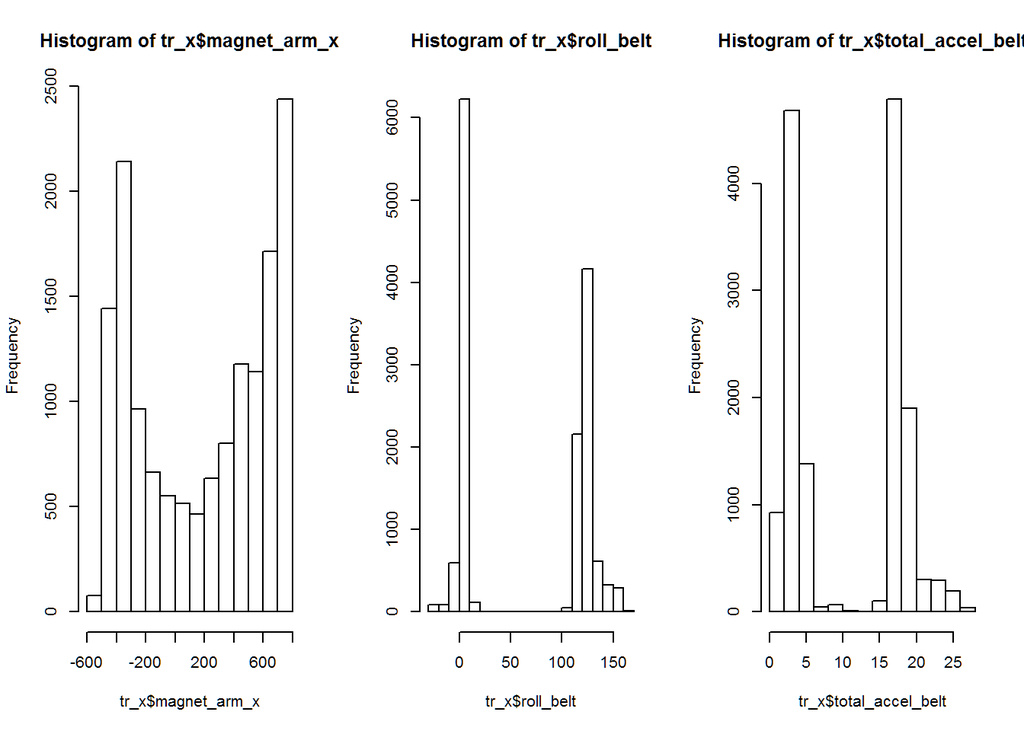

With these distributions obviously non-gaussian, a non-parametric method was selected for the analysis. The KNN method was used, using 10-fold cross-validation on the 14,718 observations in the training set. To find the best value for K, tuneLength of 10 was set. Also, all variables were standardized to avoid problems from scaling differences.

```r
set.seed(2701)
ctrl <- trainControl(method="repeatedcv",repeats = 1)
ModelFit <- train(classe ~ ., data = tr_x, method = "knn", trControl = ctrl, preProcess = c("center","scale"), tuneLength = 10)
ModelFit
```

```
## k-Nearest Neighbors
##
## 14718 samples
##    52 predictor
##     5 classes: 'A', 'B', 'C', 'D', 'E'
##
## Pre-processing: centered (52), scaled (52)
## Resampling: Cross-Validated (10 fold, repeated 1 times)
## Summary of sample sizes: 13245, 13248, 13246, 13245, 13247, 13245, ...
## Resampling results across tuning parameters:
##
##   k   Accuracy   Kappa      Accuracy SD  Kappa SD
##    5  0.9622226  0.9522103  0.004681722  0.005920779
##    7  0.9508081  0.9377565  0.006199968  0.007841408
##    9  0.9400728  0.9241660  0.006336852  0.008008260
##   11  0.9301542  0.9116024  0.008678552  0.010968530
##   13  0.9211165  0.9001483  0.009142259  0.011550962
##   15  0.9111302  0.8875076  0.009082170  0.011466970
##   17  0.9025004  0.8765859  0.009328506  0.011773157
##   19  0.8944837  0.8664530  0.009891708  0.012492881
##   21  0.8849033  0.8543149  0.012287680  0.015505586
##   23  0.8783818  0.8460514  0.013318457  0.016811114
##
## Accuracy was used to select the optimal model using  the largest value.
## The final value used for the model was k = 5.
```

To test the accuracy on the out-of-sample data, a confusion matrix is shown against the testing set.

```r
tr_xPred<-predict(ModelFit,tst_x)
confusionMatrix(tr_xPred,tst_x$classe)
```

```
## Confusion Matrix and Statistics
##
##           Reference
## Prediction    A    B    C    D    E
##          A 1376   28    4    0    1
##          B    9  901   12    1   10
##          C    5   17  820   25    4
##          D    4    2   17  776    5
##          E    1    1    2    2  881
##
## Overall Statistics
##
##                Accuracy : 0.9694
##                  95% CI : (0.9642, 0.9741)
##     No Information Rate : 0.2845
##     P-Value [Acc > NIR] : < 2.2e-16
##
##                   Kappa : 0.9613
##  Mcnemar's Test P-Value : 0.003873
##
## Statistics by Class:
##
##                      Class: A Class: B Class: C Class: D Class: E
## Sensitivity            0.9864   0.9494   0.9591   0.9652   0.9778
## Specificity            0.9906   0.9919   0.9874   0.9932   0.9985
## Pos Pred Value         0.9766   0.9657   0.9414   0.9652   0.9932
## Neg Pred Value         0.9946   0.9879   0.9913   0.9932   0.9950
## Prevalence             0.2845   0.1935   0.1743   0.1639   0.1837
## Detection Rate         0.2806   0.1837   0.1672   0.1582   0.1796
## Detection Prevalence   0.2873   0.1903   0.1776   0.1639   0.1809
## Balanced Accuracy      0.9885   0.9707   0.9732   0.9792   0.9882
```

The expected error rate, therefore, is 1-96.9%, or just over 3%.

Predictions for the 20-line test set supplied are:

```r
 tst_x0<-pmltst[,-Exclude]
predict(ModelFit,tst_x0)
```

```
##  [1] B A B A A E D B A A B C B A E E A B B B
## Levels: A B C D E
```